# FinalFinal1

Maliat I

12/6/2021

## R Markdown

### Overview

There are millions of stray pets around the world, some of which are fortunate enough to be adopted while many others are not. While adoption of a pet is often the definition of success, the rate at which a pet is adopted is also a key success factor - pets that take a long time to adopt contribute to over-crowded animal shelters and can prevent taking on new strays. Sadly, pets that are not adopted eventually need to be euthanized.

### Learn more about the data

[About the data](https://www.kaggle.com/c/petfinder-adoption-prediction/data)

### What to Predict

Predictor (Adoption Speed) Description: Predict how quickly, if at all, a pet is adopted.

The values are determined in the following way: 0 - Pet was adopted on the same day as it was listed. 1 - Pet was adopted between 1 and 7 days (1st week) after being listed. 2 - Pet was adopted between 8 and 30 days (1st month) after being listed. 3 - Pet was adopted between 31 and 90 days (2nd & 3rd month) after being listed. 4 - No adoption after 100 days of being listed.

### This Notebook…

The data has no missing values, but there are a number of features in text that need to be converted to some numeric value. This notebook performs those changes.

```r
knitr::opts_chunk$set(echo = TRUE)
knitr::opts_chunk$set(message = FALSE)
knitr::opts_chunk$set(warning = FALSE)
```

```r
library(dplyr)
library(reshape)
library(ggplot2)
library(purrr)
library(psych)
library(tidyr)
```

```r
library(scales)
```

### Load Data

Load the data

```
##   Type                  Name Age Breed1 Breed2 Gender Color1 Color2 Color3
## 1    1              Lil Milo   2      0     26      2      2      0      0
## 2    1 Bella 4 Months Puppy!   4      0    307      2      2      3      0
##   MaturitySize FurLength Vaccinated Dewormed Sterilized Health Quantity Fee
## 1            2         1          1        1          2      1        1   0
## 2            2         1          1        1          2      1        1 100
##   State                        RescuerID VideoAmt
## 1 41326 1a2113010d6048d5410b265347b35c91        0
## 2 41326 3673e167fc9932b13149bed1f2a0180a        0
##                                                                                                                                                                                                                             Description
## 1                                              Milo went missing after a week with her new adoptive family. Only 3 months old, light brown coat. Missing from Jalan Kiara, Bandar Botanic, Klang. Please call Su at if you've seen her.
## 2 She's only 4 months old, very friendly and loving. Loves attention. A little naughty sometimes. But she's adorable. I adopted her from MDDB, but recently I have just moved to a condo. Im finding a perfect and loving home for her.
##       PetID PhotoAmt AdoptionSpeed
## 1 375905770        3             3
## 2 da8d4a273        5             4
```

### Missing Values Count

There are no missing values

```r
map(data, ~sum(is.na(.))) %>% t()
```

```
##      Type Name Age Breed1 Breed2 Gender Color1 Color2 Color3 MaturitySize
## [1,] 0    0    0   0      0      0      0      0      0      0
##      FurLength Vaccinated Dewormed Sterilized Health Quantity Fee State
## [1,] 0         0          0        0          0      0        0   0
##      RescuerID VideoAmt Description PetID PhotoAmt AdoptionSpeed
## [1,] 0         0        0           0     0        0
```

### Show the type of each data

```r
str(data)
```

```
## 'data.frame':    14993 obs. of  24 variables:
##  $ Type         : int  1 1 2 1 1 1 1 1 1 1 ...
##  $ Name         : chr  "Lil Milo" "Bella 4 Months Puppy!" "" "\"Boy Boy\"" ...
##  $ Age          : int  2 4 3 72 2 5 24 3 0 24 ...
##  $ Breed1       : int  0 0 0 0 0 1 1 3 5 5 ...
##  $ Breed2       : int  26 307 266 307 205 0 0 0 0 307 ...
##  $ Gender       : int  2 2 3 1 2 2 3 1 2 2 ...
##  $ Color1       : int  2 2 1 1 2 1 4 2 1 3 ...
##  $ Color2       : int  0 3 4 2 5 4 0 0 2 5 ...
##  $ Color3       : int  0 0 7 0 7 7 0 0 0 0 ...
##  $ MaturitySize : int  2 2 1 2 1 2 2 2 1 2 ...
##  $ FurLength    : int  1 1 1 2 1 1 1 2 1 2 ...
##  $ Vaccinated   : int  1 1 2 2 2 2 1 2 2 1 ...
##  $ Dewormed     : int  1 1 1 2 2 2 1 1 2 1 ...
##  $ Sterilized   : int  2 2 2 2 2 2 1 2 2 1 ...
##  $ Health       : int  1 1 1 1 1 1 1 1 2 1 ...
##  $ Quantity     : int  1 1 3 1 1 2 2 4 1 1 ...
##  $ Fee          : int  0 100 0 0 1 0 0 0 0 0 ...
##  $ State        : int  41326 41326 41401 41326 41336 41326 41330 41326 41401 41326 ...
##  $ RescuerID    : chr  "1a2113010d6048d5410b265347b35c91" "3673e167fc9932b13149bed1f2a0180a" "f7cff59d10c867bdee12c3f35f34d086" "94b991f8dc1e0bb903ca8d4d492c8d43" ...
##  $ VideoAmt     : int  0 0 0 0 0 0 0 0 0 0 ...
##  $ Description  : chr  "Milo went missing after a week with her new adoptive family. Only 3 months old, light brown coat. Missing from "| __truncated__ "She's only 4 months old, very friendly and loving. Loves attention. A little naughty sometimes. But she's adora"| __truncated__ "Mama cat came t…
##  $ PetID        : chr  "375905770" "da8d4a273" "27e74e45c" "7b5bee232" ...
##  $ PhotoAmt     : int  3 5 11 5 0 2 5 3 2 2 ...
##  $ AdoptionSpeed: int  3 4 2 4 3 4 4 4 1 4 ...
```

### It can be observed that the rate of not getting adopted after 100 days of being listed is more frequent.

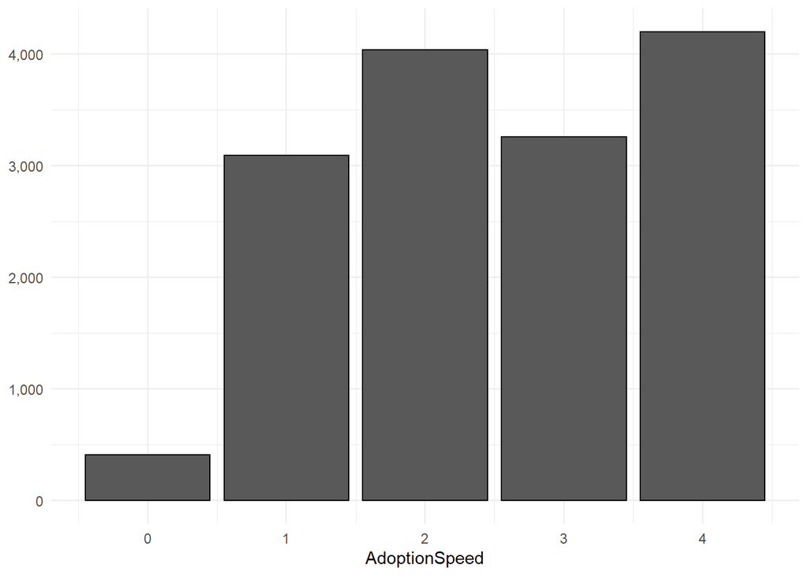

```r
 data %>%
  ggplot(aes(x= AdoptionSpeed, fill = AdoptionSpeed)) +
  geom_bar(stat = "count", color = "black") +
  theme_minimal() +
  theme(axis.title.y = element_blank()) +
  scale_y_continuous(labels = comma) +
  scale_fill_brewer(palette="blue") +
  theme(legend.position = "top")
```

### Exploration

```r
library(tidyverse)
library(jsonlite)
library(scales)
library(lubridate)
library(repr)
library(ggrepel)
library(gridExtra)
library(tidytext)
library(grid)
library(rjson)
library(xgboost)
library(caret)
library(Metrics)
library(Ckmeans.1d.dp)
```

```r
library(dplyr)
train <- read_csv("https://raw.githubusercontent.com/akarimhammoud/Data_621/main/Final%20Project/data/TrainingData/train.csv")
test <- read_csv("https://raw.githubusercontent.com/akarimhammoud/Data_621/main/Final%20Project/data/TestData/test.csv")
state_labels <- read_csv("https://raw.githubusercontent.com/akarimhammoud/Data_621/main/Final%20Project/data/state_labels.csv")
breed_labels <- read_csv("https://raw.githubusercontent.com/akarimhammoud/Data_621/main/Final%20Project/data/TrainingData/breed_labels.csv")
color_labels <- read_csv("https://raw.githubusercontent.com/akarimhammoud/Data_621/main/Final%20Project/data/color_labels.csv")
tr_te <- bind_rows(train, test)


train <- left_join(train, breed_labels %>%dplyr:: select(Breed1=BreedID, MainBreed=BreedName), by="Breed1")
train <- left_join(train, breed_labels %>%dplyr:: select(Breed2=BreedID, SecondBreed=BreedName), by="Breed2")
train <- left_join(train, color_labels %>%dplyr:: select(Color1=ColorID, ColorName1=ColorName), by="Color1")
train <- left_join(train, color_labels %>% dplyr::select(Color2=ColorID, ColorName2=ColorName), by="Color2")
train <- left_join(train, color_labels %>% dplyr::select(Color3=ColorID, ColorName3=ColorName), by="Color3")

train <- train %>% dplyr::select(-State, -Breed1, -Breed2, - Color1, -Color2, -Color3)

train <- train %>% mutate_at(vars(Type, Gender, AdoptionSpeed), as.factor)
train <- train %>% mutate(Type=recode(Type, "1"= "Dog", "2"= "Cat"),
                         Gender=recode(Gender, "1"= "Male", "2" = "Female", "3"= "Mixed"),
                         AdoptionSpeed=recode(AdoptionSpeed,
                                              "0"= "0 - Adopted on the same day",
                                              "1" = "1 - Adopted between 1 and 7 days",
                                              "2" = "2 - Adopted between 8 and 30 days",
                                             "3" = "3 - Adopted between 31 and 90 days",
                                            "4" = "4 - No adoption after 100 days"))
train <- train %>% mutate_if(is_character, as_factor)
glimpse(train)
```

```
## Rows: 14,993
## Columns: 23
## $ Type          <fct> Dog, Dog, Cat, Dog, Dog, Dog, Dog, Dog, Dog, Dog, Dog, D~
## $ Name          <fct> "Lil Milo", "Bella 4 Months Puppy!", NA, "\"Boy Boy\"", ~
## $ Age           <dbl> 2, 4, 3, 72, 2, 5, 24, 3, 0, 24, 14, 60, 84, 21, 1, 1, 1~
## $ Gender        <fct> Female, Female, Mixed, Male, Female, Female, Mixed, Male~
## $ MaturitySize  <dbl> 2, 2, 1, 2, 1, 2, 2, 2, 1, 2, 2, 2, 2, 2, 2, 2, 2, 2, 2,~
## $ FurLength     <dbl> 1, 1, 1, 2, 1, 1, 1, 2, 1, 2, 1, 1, 1, 1, 3, 2, 1, 2, 3,~
## $ Vaccinated    <dbl> 1, 1, 2, 2, 2, 2, 1, 2, 2, 1, 1, 1, 1, 1, 2, 2, 2, 1, 1,~
## $ Dewormed      <dbl> 1, 1, 1, 2, 2, 2, 1, 1, 2, 1, 1, 1, 1, 1, 2, 2, 2, 3, 1,~
## $ Sterilized    <dbl> 2, 2, 2, 2, 2, 2, 1, 2, 2, 1, 3, 1, 2, 1, 2, 2, 2, 3, 1,~
## $ Health        <dbl> 1, 1, 1, 1, 1, 1, 1, 1, 2, 1, 1, 1, 1, 2, 1, 1, 1, 1, 1,~
## $ Quantity      <dbl> 1, 1, 3, 1, 1, 2, 2, 4, 1, 1, 1, 1, 1, 1, 1, 1, 1, 1, 1,~
## $ Fee           <dbl> 0, 100, 0, 0, 1, 0, 0, 0, 0, 0, 500, 0, 0, 0, 0, 0, 0, 0~
## $ RescuerID     <fct> 1a2113010d6048d5410b265347b35c91, 3673e167fc9932b13149be~
## $ VideoAmt      <dbl> 0, 0, 0, 0, 0, 0, 0, 0, 0, 0, 0, 0, 0, 0, 0, 0, 0, 0, 0,~
## $ Description   <fct> "Milo went missing after a week with her new adoptive fa~
## $ PetID         <fct> 375905770, da8d4a273, 27e74e45c, 7b5bee232, 0327b8e94, f~
## $ PhotoAmt      <dbl> 3, 5, 11, 5, 0, 2, 5, 3, 2, 2, 2, 2, 1, 2, 4, 4, 3, 1, 3~
## $ AdoptionSpeed <fct> 3 - Adopted between 31 and 90 days, 4 - No adoption afte~
## $ MainBreed     <fct> NA, NA, NA, NA, NA, Affenpinscher, Affenpinscher, Aireda~
## $ SecondBreed   <fct> Belgian Shepherd Malinois, Mixed Breed, Dom Short Hair, ~
## $ ColorName1    <fct> Brown, Brown, Black, Black, Brown, Black, Yellow, Brown,~
## $ ColorName2    <fct> NA, Golden, Yellow, Brown, Cream, Yellow, NA, NA, Brown,~
## $ ColorName3    <fct> NA, NA, White, NA, White, White, NA, NA, NA, NA, NA, NA,~
```

### Pure Breed Feature:

### We will observe if pure breed pets are getting adopted faster than the pets that are not pure breed.

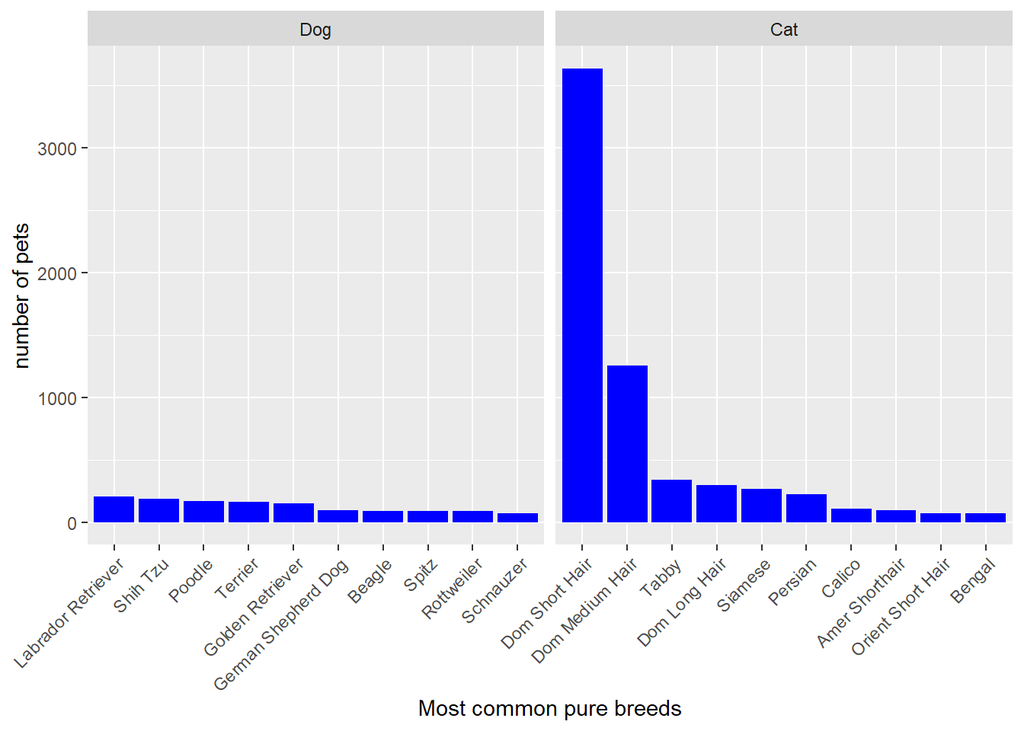

```r
not_pure <- c("Domestic Short Hair", "Domestic Medium Hair", "Domestic Long Hair", "Mixed Breed")
train$pure_breed <- ifelse(train$MainBreed %in% not_pure, 0, 1)

train %>% filter(pure_breed==1) %>% count(Type, MainBreed) %>% group_by(Type) %>% top_n(10, n) %>%
ggplot(aes(x=reorder(MainBreed, -n), y=n))+
geom_bar(stat="identity", fill="blue") +
facet_wrap(~Type, scales = "free_x") +
theme(axis.text.x = element_text(angle = 45, hjust = 1)) +
labs(x="Most common pure breeds", y="number of pets")
```

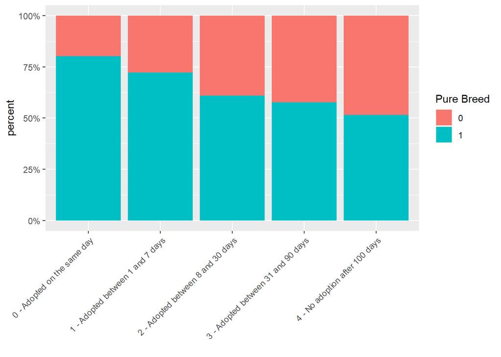

```r
train %>% count(AdoptionSpeed, pure_breed) %>%
ggplot(aes(x=AdoptionSpeed, y=n, fill=as.factor(pure_breed))) +
geom_bar(stat="identity", position="fill") +
theme(axis.text.x = element_text(angle = 45, hjust = 1)) +
guides(fill=guide_legend(title="Pure Breed")) +
scale_y_continuous(labels=percent) +
labs(x="", y="percent")
```

```r
tr_te <- left_join(tr_te, state_labels %>% dplyr::rename(State=StateID), by="State")
tr_te <- left_join(tr_te, breed_labels %>% dplyr::select(Breed1=BreedID, MainBreed=BreedName), by="Breed1")

#creating Has Name variable
tr_te$has_name <- ifelse(is.na(tr_te$Name), 0, 1)

#creating Pure Breed variable
not_pure <- c("Domestic Short Hair", "Domestic Medium Hair", "Domestic Long Hair", "Mixed Breed")
tr_te$pure_breed <- ifelse(tr_te$MainBreed %in% not_pure, 0, 1)

#making Not Specified in ordinal factors NA (just in case there are any in stage 2)
tr_te$MaturitySize[tr_te$MaturitySize==0] <- NA
tr_te$FurLength[tr_te$FurLength==0] <- NA
tr_te$Health[tr_te$Health==0] <- NA

categorical_vars <- c("Type", "Gender", "Vaccinated", "Dewormed", "Sterilized", "StateName", "MainBreed", "has_name", "pure_breed", "Breed2", "Color1", "Color2", "Color3")

tr_te <- tr_te %>% dplyr::select(-Name, -Breed1, -RescuerID, -Description, -State, -PetID) %>%
mutate_at(categorical_vars, funs(factor(.))) %>% mutate_if(is.numeric, as.integer)

glimpse(tr_te)
```

```
## Rows: 18,941
## Columns: 22
## $ Type          <fct> 1, 1, 2, 1, 1, 1, 1, 1, 1, 1, 1, 1, 1, 1, 1, 1, 1, 1, 1,~
## $ Age           <int> 2, 4, 3, 72, 2, 5, 24, 3, 0, 24, 14, 60, 84, 21, 1, 1, 1~
## $ Breed2        <fct> 26, 307, 266, 307, 205, 0, 0, 0, 0, 307, 0, 0, 0, 307, 0~
## $ Gender        <fct> 2, 2, 3, 1, 2, 2, 3, 1, 2, 2, 1, 2, 1, 2, 2, 2, 2, 2, 1,~
## $ Color1        <fct> 2, 2, 1, 1, 2, 1, 4, 2, 1, 3, 2, 1, 2, 2, 7, 2, 2, 1, 1,~
## $ Color2        <fct> 0, 3, 4, 2, 5, 4, 0, 0, 2, 5, 0, 7, 0, 7, 0, 0, 6, 2, 2,~
## $ Color3        <fct> 0, 0, 7, 0, 7, 7, 0, 0, 0, 0, 0, 0, 0, 0, 0, 0, 7, 0, 0,~
## $ MaturitySize  <int> 2, 2, 1, 2, 1, 2, 2, 2, 1, 2, 2, 2, 2, 2, 2, 2, 2, 2, 2,~
## $ FurLength     <int> 1, 1, 1, 2, 1, 1, 1, 2, 1, 2, 1, 1, 1, 1, 3, 2, 1, 2, 3,~
## $ Vaccinated    <fct> 1, 1, 2, 2, 2, 2, 1, 2, 2, 1, 1, 1, 1, 1, 2, 2, 2, 1, 1,~
## $ Dewormed      <fct> 1, 1, 1, 2, 2, 2, 1, 1, 2, 1, 1, 1, 1, 1, 2, 2, 2, 3, 1,~
## $ Sterilized    <fct> 2, 2, 2, 2, 2, 2, 1, 2, 2, 1, 3, 1, 2, 1, 2, 2, 2, 3, 1,~
## $ Health        <int> 1, 1, 1, 1, 1, 1, 1, 1, 2, 1, 1, 1, 1, 2, 1, 1, 1, 1, 1,~
## $ Quantity      <int> 1, 1, 3, 1, 1, 2, 2, 4, 1, 1, 1, 1, 1, 1, 1, 1, 1, 1, 1,~
## $ Fee           <int> 0, 100, 0, 0, 1, 0, 0, 0, 0, 0, 500, 0, 0, 0, 0, 0, 0, 0~
## $ VideoAmt      <int> 0, 0, 0, 0, 0, 0, 0, 0, 0, 0, 0, 0, 0, 0, 0, 0, 0, 0, 0,~
## $ PhotoAmt      <int> 3, 5, 11, 5, 0, 2, 5, 3, 2, 2, 2, 2, 1, 2, 4, 4, 3, 1, 3~
## $ AdoptionSpeed <int> 3, 4, 2, 4, 3, 4, 4, 4, 1, 4, 4, 3, 3, 3, 4, 4, 1, 4, 4,~
## $ StateName     <fct> Selangor, Selangor, Kuala Lumpur, Selangor, Johor, Selan~
## $ MainBreed     <fct> NA, NA, NA, NA, NA, Affenpinscher, Affenpinscher, Aireda~
## $ has_name      <fct> 1, 1, 0, 1, 1, 1, 1, 1, 1, 1, 0, 1, 1, 1, 1, 1, 1, 1, 1,~
## $ pure_breed    <fct> 1, 1, 1, 1, 1, 1, 1, 1, 1, 1, 1, 1, 1, 1, 1, 1, 1, 1, 1,~
```

```r
glimpse(train)
```

```
## Rows: 14,993
## Columns: 24
## $ Type          <fct> Dog, Dog, Cat, Dog, Dog, Dog, Dog, Dog, Dog, Dog, Dog, D~
## $ Name          <fct> "Lil Milo", "Bella 4 Months Puppy!", NA, "\"Boy Boy\"", ~
## $ Age           <dbl> 2, 4, 3, 72, 2, 5, 24, 3, 0, 24, 14, 60, 84, 21, 1, 1, 1~
## $ Gender        <fct> Female, Female, Mixed, Male, Female, Female, Mixed, Male~
## $ MaturitySize  <dbl> 2, 2, 1, 2, 1, 2, 2, 2, 1, 2, 2, 2, 2, 2, 2, 2, 2, 2, 2,~
## $ FurLength     <dbl> 1, 1, 1, 2, 1, 1, 1, 2, 1, 2, 1, 1, 1, 1, 3, 2, 1, 2, 3,~
## $ Vaccinated    <dbl> 1, 1, 2, 2, 2, 2, 1, 2, 2, 1, 1, 1, 1, 1, 2, 2, 2, 1, 1,~
## $ Dewormed      <dbl> 1, 1, 1, 2, 2, 2, 1, 1, 2, 1, 1, 1, 1, 1, 2, 2, 2, 3, 1,~
## $ Sterilized    <dbl> 2, 2, 2, 2, 2, 2, 1, 2, 2, 1, 3, 1, 2, 1, 2, 2, 2, 3, 1,~
## $ Health        <dbl> 1, 1, 1, 1, 1, 1, 1, 1, 2, 1, 1, 1, 1, 2, 1, 1, 1, 1, 1,~
## $ Quantity      <dbl> 1, 1, 3, 1, 1, 2, 2, 4, 1, 1, 1, 1, 1, 1, 1, 1, 1, 1, 1,~
## $ Fee           <dbl> 0, 100, 0, 0, 1, 0, 0, 0, 0, 0, 500, 0, 0, 0, 0, 0, 0, 0~
## $ RescuerID     <fct> 1a2113010d6048d5410b265347b35c91, 3673e167fc9932b13149be~
## $ VideoAmt      <dbl> 0, 0, 0, 0, 0, 0, 0, 0, 0, 0, 0, 0, 0, 0, 0, 0, 0, 0, 0,~
## $ Description   <fct> "Milo went missing after a week with her new adoptive fa~
## $ PetID         <fct> 375905770, da8d4a273, 27e74e45c, 7b5bee232, 0327b8e94, f~
## $ PhotoAmt      <dbl> 3, 5, 11, 5, 0, 2, 5, 3, 2, 2, 2, 2, 1, 2, 4, 4, 3, 1, 3~
## $ AdoptionSpeed <fct> 3 - Adopted between 31 and 90 days, 4 - No adoption afte~
## $ MainBreed     <fct> NA, NA, NA, NA, NA, Affenpinscher, Affenpinscher, Aireda~
## $ SecondBreed   <fct> Belgian Shepherd Malinois, Mixed Breed, Dom Short Hair, ~
## $ ColorName1    <fct> Brown, Brown, Black, Black, Brown, Black, Yellow, Brown,~
## $ ColorName2    <fct> NA, Golden, Yellow, Brown, Cream, Yellow, NA, NA, Brown,~
## $ ColorName3    <fct> NA, NA, White, NA, White, White, NA, NA, NA, NA, NA, NA,~
## $ pure_breed    <dbl> 1, 1, 1, 1, 1, 1, 1, 1, 1, 1, 1, 1, 1, 1, 1, 1, 1, 1, 1,~
```

```r
glimpse(tr_te)
```

```
## Rows: 18,941
## Columns: 22
## $ Type          <fct> 1, 1, 2, 1, 1, 1, 1, 1, 1, 1, 1, 1, 1, 1, 1, 1, 1, 1, 1,~
## $ Age           <int> 2, 4, 3, 72, 2, 5, 24, 3, 0, 24, 14, 60, 84, 21, 1, 1, 1~
## $ Breed2        <fct> 26, 307, 266, 307, 205, 0, 0, 0, 0, 307, 0, 0, 0, 307, 0~
## $ Gender        <fct> 2, 2, 3, 1, 2, 2, 3, 1, 2, 2, 1, 2, 1, 2, 2, 2, 2, 2, 1,~
## $ Color1        <fct> 2, 2, 1, 1, 2, 1, 4, 2, 1, 3, 2, 1, 2, 2, 7, 2, 2, 1, 1,~
## $ Color2        <fct> 0, 3, 4, 2, 5, 4, 0, 0, 2, 5, 0, 7, 0, 7, 0, 0, 6, 2, 2,~
## $ Color3        <fct> 0, 0, 7, 0, 7, 7, 0, 0, 0, 0, 0, 0, 0, 0, 0, 0, 7, 0, 0,~
## $ MaturitySize  <int> 2, 2, 1, 2, 1, 2, 2, 2, 1, 2, 2, 2, 2, 2, 2, 2, 2, 2, 2,~
## $ FurLength     <int> 1, 1, 1, 2, 1, 1, 1, 2, 1, 2, 1, 1, 1, 1, 3, 2, 1, 2, 3,~
## $ Vaccinated    <fct> 1, 1, 2, 2, 2, 2, 1, 2, 2, 1, 1, 1, 1, 1, 2, 2, 2, 1, 1,~
## $ Dewormed      <fct> 1, 1, 1, 2, 2, 2, 1, 1, 2, 1, 1, 1, 1, 1, 2, 2, 2, 3, 1,~
## $ Sterilized    <fct> 2, 2, 2, 2, 2, 2, 1, 2, 2, 1, 3, 1, 2, 1, 2, 2, 2, 3, 1,~
## $ Health        <int> 1, 1, 1, 1, 1, 1, 1, 1, 2, 1, 1, 1, 1, 2, 1, 1, 1, 1, 1,~
## $ Quantity      <int> 1, 1, 3, 1, 1, 2, 2, 4, 1, 1, 1, 1, 1, 1, 1, 1, 1, 1, 1,~
## $ Fee           <int> 0, 100, 0, 0, 1, 0, 0, 0, 0, 0, 500, 0, 0, 0, 0, 0, 0, 0~
## $ VideoAmt      <int> 0, 0, 0, 0, 0, 0, 0, 0, 0, 0, 0, 0, 0, 0, 0, 0, 0, 0, 0,~
## $ PhotoAmt      <int> 3, 5, 11, 5, 0, 2, 5, 3, 2, 2, 2, 2, 1, 2, 4, 4, 3, 1, 3~
## $ AdoptionSpeed <int> 3, 4, 2, 4, 3, 4, 4, 4, 1, 4, 4, 3, 3, 3, 4, 4, 1, 4, 4,~
## $ StateName     <fct> Selangor, Selangor, Kuala Lumpur, Selangor, Johor, Selan~
## $ MainBreed     <fct> NA, NA, NA, NA, NA, Affenpinscher, Affenpinscher, Aireda~
## $ has_name      <fct> 1, 1, 0, 1, 1, 1, 1, 1, 1, 1, 0, 1, 1, 1, 1, 1, 1, 1, 1,~
## $ pure_breed    <fct> 1, 1, 1, 1, 1, 1, 1, 1, 1, 1, 1, 1, 1, 1, 1, 1, 1, 1, 1,~
```

#### Fast adoption:

### Adoption speed less than 3 is categorized as high(1) and more than 3 is categorized as low(0).

```r
High = ifelse(tr_te$AdoptionSpeed<3, "1", "0")
tr_te = data.frame(tr_te, High)
```

```r
glimpse(tr_te)
```

```
## Rows: 18,941
## Columns: 23
## $ Type          <fct> 1, 1, 2, 1, 1, 1, 1, 1, 1, 1, 1, 1, 1, 1, 1, 1, 1, 1, 1,~
## $ Age           <int> 2, 4, 3, 72, 2, 5, 24, 3, 0, 24, 14, 60, 84, 21, 1, 1, 1~
## $ Breed2        <fct> 26, 307, 266, 307, 205, 0, 0, 0, 0, 307, 0, 0, 0, 307, 0~
## $ Gender        <fct> 2, 2, 3, 1, 2, 2, 3, 1, 2, 2, 1, 2, 1, 2, 2, 2, 2, 2, 1,~
## $ Color1        <fct> 2, 2, 1, 1, 2, 1, 4, 2, 1, 3, 2, 1, 2, 2, 7, 2, 2, 1, 1,~
## $ Color2        <fct> 0, 3, 4, 2, 5, 4, 0, 0, 2, 5, 0, 7, 0, 7, 0, 0, 6, 2, 2,~
## $ Color3        <fct> 0, 0, 7, 0, 7, 7, 0, 0, 0, 0, 0, 0, 0, 0, 0, 0, 7, 0, 0,~
## $ MaturitySize  <int> 2, 2, 1, 2, 1, 2, 2, 2, 1, 2, 2, 2, 2, 2, 2, 2, 2, 2, 2,~
## $ FurLength     <int> 1, 1, 1, 2, 1, 1, 1, 2, 1, 2, 1, 1, 1, 1, 3, 2, 1, 2, 3,~
## $ Vaccinated    <fct> 1, 1, 2, 2, 2, 2, 1, 2, 2, 1, 1, 1, 1, 1, 2, 2, 2, 1, 1,~
## $ Dewormed      <fct> 1, 1, 1, 2, 2, 2, 1, 1, 2, 1, 1, 1, 1, 1, 2, 2, 2, 3, 1,~
## $ Sterilized    <fct> 2, 2, 2, 2, 2, 2, 1, 2, 2, 1, 3, 1, 2, 1, 2, 2, 2, 3, 1,~
## $ Health        <int> 1, 1, 1, 1, 1, 1, 1, 1, 2, 1, 1, 1, 1, 2, 1, 1, 1, 1, 1,~
## $ Quantity      <int> 1, 1, 3, 1, 1, 2, 2, 4, 1, 1, 1, 1, 1, 1, 1, 1, 1, 1, 1,~
## $ Fee           <int> 0, 100, 0, 0, 1, 0, 0, 0, 0, 0, 500, 0, 0, 0, 0, 0, 0, 0~
## $ VideoAmt      <int> 0, 0, 0, 0, 0, 0, 0, 0, 0, 0, 0, 0, 0, 0, 0, 0, 0, 0, 0,~
## $ PhotoAmt      <int> 3, 5, 11, 5, 0, 2, 5, 3, 2, 2, 2, 2, 1, 2, 4, 4, 3, 1, 3~
## $ AdoptionSpeed <int> 3, 4, 2, 4, 3, 4, 4, 4, 1, 4, 4, 3, 3, 3, 4, 4, 1, 4, 4,~
## $ StateName     <fct> Selangor, Selangor, Kuala Lumpur, Selangor, Johor, Selan~
## $ MainBreed     <fct> NA, NA, NA, NA, NA, Affenpinscher, Affenpinscher, Aireda~
## $ has_name      <fct> 1, 1, 0, 1, 1, 1, 1, 1, 1, 1, 0, 1, 1, 1, 1, 1, 1, 1, 1,~
## $ pure_breed    <fct> 1, 1, 1, 1, 1, 1, 1, 1, 1, 1, 1, 1, 1, 1, 1, 1, 1, 1, 1,~
## $ High          <chr> "0", "0", "1", "0", "0", "0", "0", "0", "1", "0", "0", "~
```

```r
tr_te$High<-as.numeric(tr_te$High)
```

```r
glimpse(tr_te)
```

```
## Rows: 18,941
## Columns: 23
## $ Type          <fct> 1, 1, 2, 1, 1, 1, 1, 1, 1, 1, 1, 1, 1, 1, 1, 1, 1, 1, 1,~
## $ Age           <int> 2, 4, 3, 72, 2, 5, 24, 3, 0, 24, 14, 60, 84, 21, 1, 1, 1~
## $ Breed2        <fct> 26, 307, 266, 307, 205, 0, 0, 0, 0, 307, 0, 0, 0, 307, 0~
## $ Gender        <fct> 2, 2, 3, 1, 2, 2, 3, 1, 2, 2, 1, 2, 1, 2, 2, 2, 2, 2, 1,~
## $ Color1        <fct> 2, 2, 1, 1, 2, 1, 4, 2, 1, 3, 2, 1, 2, 2, 7, 2, 2, 1, 1,~
## $ Color2        <fct> 0, 3, 4, 2, 5, 4, 0, 0, 2, 5, 0, 7, 0, 7, 0, 0, 6, 2, 2,~
## $ Color3        <fct> 0, 0, 7, 0, 7, 7, 0, 0, 0, 0, 0, 0, 0, 0, 0, 0, 7, 0, 0,~
## $ MaturitySize  <int> 2, 2, 1, 2, 1, 2, 2, 2, 1, 2, 2, 2, 2, 2, 2, 2, 2, 2, 2,~
## $ FurLength     <int> 1, 1, 1, 2, 1, 1, 1, 2, 1, 2, 1, 1, 1, 1, 3, 2, 1, 2, 3,~
## $ Vaccinated    <fct> 1, 1, 2, 2, 2, 2, 1, 2, 2, 1, 1, 1, 1, 1, 2, 2, 2, 1, 1,~
## $ Dewormed      <fct> 1, 1, 1, 2, 2, 2, 1, 1, 2, 1, 1, 1, 1, 1, 2, 2, 2, 3, 1,~
## $ Sterilized    <fct> 2, 2, 2, 2, 2, 2, 1, 2, 2, 1, 3, 1, 2, 1, 2, 2, 2, 3, 1,~
## $ Health        <int> 1, 1, 1, 1, 1, 1, 1, 1, 2, 1, 1, 1, 1, 2, 1, 1, 1, 1, 1,~
## $ Quantity      <int> 1, 1, 3, 1, 1, 2, 2, 4, 1, 1, 1, 1, 1, 1, 1, 1, 1, 1, 1,~
## $ Fee           <int> 0, 100, 0, 0, 1, 0, 0, 0, 0, 0, 500, 0, 0, 0, 0, 0, 0, 0~
## $ VideoAmt      <int> 0, 0, 0, 0, 0, 0, 0, 0, 0, 0, 0, 0, 0, 0, 0, 0, 0, 0, 0,~
## $ PhotoAmt      <int> 3, 5, 11, 5, 0, 2, 5, 3, 2, 2, 2, 2, 1, 2, 4, 4, 3, 1, 3~
## $ AdoptionSpeed <int> 3, 4, 2, 4, 3, 4, 4, 4, 1, 4, 4, 3, 3, 3, 4, 4, 1, 4, 4,~
## $ StateName     <fct> Selangor, Selangor, Kuala Lumpur, Selangor, Johor, Selan~
## $ MainBreed     <fct> NA, NA, NA, NA, NA, Affenpinscher, Affenpinscher, Aireda~
## $ has_name      <fct> 1, 1, 0, 1, 1, 1, 1, 1, 1, 1, 0, 1, 1, 1, 1, 1, 1, 1, 1,~
## $ pure_breed    <fct> 1, 1, 1, 1, 1, 1, 1, 1, 1, 1, 1, 1, 1, 1, 1, 1, 1, 1, 1,~
## $ High          <dbl> 0, 0, 1, 0, 0, 0, 0, 0, 1, 0, 0, 0, 0, 0, 0, 0, 1, 0, 0,~
```

```r
library(MASS)
modelnegb <- glm.nb(High ~ ., data = tr_te)
```

### Negative Binomial Model:

```r
summary(modelnegb)
```

```
##
## Call:
## glm.nb(formula = High ~ ., data = tr_te, init.theta = 23950.02709,
##     link = log)
##
## Deviance Residuals:
##     Min       1Q   Median       3Q      Max
## -1.4076  -0.4663  -0.3909   0.5029   1.1392
##
## Coefficients: (3 not defined because of singularities)
##                                                          Estimate Std. Error
## (Intercept)                                             1.630e+00  7.223e-01
## Type2                                                  -7.824e-01  6.447e-01
## Age                                                    -4.571e-04  9.434e-04
## Breed21                                                 5.644e-01  1.001e+00
## Breed22                                                -2.885e-01  1.008e+00
## Breed24                                                -1.951e-01  1.029e+00
## Breed25                                                -1.051e-01  7.890e-01
## Breed210                                                4.339e-01  1.021e+00
## Breed214                                               -3.511e+01  4.745e+07
## Breed216                                                2.495e-01  7.414e-01
## Breed217                                               -3.466e+01  6.711e+07
## Breed218                                                1.539e-01  1.004e+00
## Breed219                                                5.096e-01  1.019e+00
## Breed220                                                7.630e-02  3.000e-01
## Breed221                                               -3.508e+01  4.745e+07
## Breed224                                               -4.349e-01  5.807e-01
## Breed225                                                3.302e+01  4.263e+07
## Breed226                                                4.186e-01  2.705e-01
## Breed236                                               -3.549e+01  6.711e+07
## Breed239                                                2.013e-01  4.491e-01
## Breed240                                               -3.550e+01  6.711e+07
## Breed244                                                2.565e-01  6.138e-01
## Breed249                                                2.886e-01  1.001e+00
## Breed250                                                3.766e-01  7.244e-01
## Breed258                                               -3.472e+01  6.711e+07
## Breed260                                               -1.083e-01  5.164e-01
## Breed265                                                1.113e-01  1.229e+00
## Breed269                                                4.511e-02  5.407e-01
## Breed270                                                5.456e-02  5.827e-01
```

[output cut: 693 more lines]

```
## (Dispersion parameter for Negative Binomial(23950.02) family taken to be 1)
##
##     Null deviance: 10362.7  on 14987  degrees of freedom
## Residual deviance:  4204.6  on 14632  degrees of freedom
##   (3953 observations deleted due to missingness)
## AIC: 19991
##
## Number of Fisher Scoring iterations: 1
##
##
##               Theta:  23950
##           Std. Err.:  27269
## Warning while fitting theta: alternation limit reached
##
##  2 x log-likelihood:  -19276.89
```

### Dividing into train and test set

### Data is now partitioned into 70% train and 30% test.

```r
set.seed(100)

index = sample(1:nrow(newtr_te), 0.7*nrow(newtr_te))

train1 = newtr_te[index,] # Create the training data
test1 = newtr_te[-index,] # Create the test data

dim(train1)
```

```
## [1] 13258    17
```

```r
dim(test1)
```

```
## [1] 5683   17
```

### Negative binomial model:

```r
modelnegb1 <- glm.nb(High ~ ., data = train1)
```

```r
summary(modelnegb1)
```

```
##
## Call:
## glm.nb(formula = High ~ ., data = train1, init.theta = 16669.18195,
##     link = log)
##
## Deviance Residuals:
##     Min       1Q   Median       3Q      Max
## -1.5052  -0.9488  -0.1298   0.5660   1.5594
##
## Coefficients: (1 not defined because of singularities)
##                                                          Estimate Std. Error
## (Intercept)                                            -6.631e-01  7.002e-01
## Type2                                                  -3.317e-01  6.040e-01
## Age                                                    -7.170e-03  1.165e-03
## Gender2                                                -1.136e-01  3.067e-02
## Gender3                                                -1.353e-01  5.820e-02
## Color12                                                -2.006e-02  3.640e-02
## Color13                                                 1.861e-02  5.994e-02
## Color14                                                -1.806e-01  7.463e-02
## Color15                                                 7.820e-02  5.997e-02
## Color16                                                 3.520e-02  6.857e-02
## Color17                                                 8.234e-02  6.831e-02
## MaturitySize                                           -1.509e-02  2.827e-02
## FurLength                                               7.439e-02  2.886e-02
## Vaccinated2                                             1.476e-01  4.169e-02
## Vaccinated3                                             3.792e-02  8.508e-02
## Dewormed2                                              -1.612e-02  3.885e-02
## Dewormed3                                              -3.651e-02  8.565e-02
## Sterilized2                                             4.047e-01  4.648e-02
## Sterilized3                                             2.403e-01  6.616e-02
## Health                                                 -1.618e-01  7.724e-02
## Quantity                                               -3.287e-02  1.481e-02
## Fee                                                    -3.873e-04  2.026e-04
## PhotoAmt                                                1.577e-03  4.182e-03
## MainBreedAffenpinscher                                 -3.573e+01  6.711e+07
## MainBreedAiredale Terrier                              -3.674e+01  6.711e+07
## MainBreedAkita                                          3.199e-02  1.216e+00
## MainBreedAmer Bulldog                                  -3.616e+01  6.711e+07
## MainBreedAmer Curl                                      4.082e-01  5.075e-01
## MainBreedAmer Shorthair                                 1.087e-01  3.778e-01
```

[output cut: 339 more lines]

```
## (Dispersion parameter for Negative Binomial(16669.18) family taken to be 1)
##
##     Null deviance: 7298.9  on 10503  degrees of freedom
## Residual deviance: 6757.7  on 10323  degrees of freedom
##   (2754 observations deleted due to missingness)
## AIC: 17566
##
## Number of Fisher Scoring iterations: 1
##
##
##               Theta:  16669
##           Std. Err.:  22000
## Warning while fitting theta: alternation limit reached
##
##  2 x log-likelihood:  -17202.01
```

### Negative binomial model with significant variables:

```r
modelnegb2 <- glm.nb(High~ Age  + FurLength  + Health+
                as.factor(Gender) +
                as.factor(Vaccinated) +
                as.factor(Sterilized)+
                as.factor(Color1), data = train1)

summary(modelnegb2)
```

```
##
## Call:
## glm.nb(formula = High ~ Age + FurLength + Health + as.factor(Gender) +
##     as.factor(Vaccinated) + as.factor(Sterilized) + as.factor(Color1),
##     data = train1, init.theta = 17299.81994, link = log)
##
## Deviance Residuals:
##     Min       1Q   Median       3Q      Max
## -1.3463  -0.9836  -0.6856   0.5725   1.3332
##
## Coefficients:
##                         Estimate Std. Error z value Pr(>|z|)
## (Intercept)            -1.037513   0.096130 -10.793  < 2e-16 ***
## Age                    -0.003208   0.000995  -3.225 0.001262 **
## FurLength               0.134519   0.022733   5.917 3.27e-09 ***
## Health                 -0.138554   0.075953  -1.824 0.068120 .
## as.factor(Gender)2     -0.128883   0.030167  -4.272 1.93e-05 ***
## as.factor(Gender)3     -0.219131   0.044147  -4.964 6.92e-07 ***
## as.factor(Vaccinated)2  0.132879   0.033827   3.928 8.56e-05 ***
## as.factor(Vaccinated)3  0.028352   0.054183   0.523 0.600794
## as.factor(Sterilized)2  0.414381   0.045838   9.040  < 2e-16 ***
## as.factor(Sterilized)3  0.228526   0.064635   3.536 0.000407 ***
## as.factor(Color1)2     -0.037595   0.034951  -1.076 0.282089
## as.factor(Color1)3      0.083682   0.057252   1.462 0.143843
## as.factor(Color1)4     -0.131694   0.073257  -1.798 0.072223 .
## as.factor(Color1)5      0.100691   0.058370   1.725 0.084520 .
## as.factor(Color1)6      0.133284   0.065103   2.047 0.040630 *
## as.factor(Color1)7      0.104872   0.065793   1.594 0.110941
## ---
## Signif. codes:  0 '***' 0.001 '**' 0.01 '*' 0.05 '.' 0.1 ' ' 1
##
## (Dispersion parameter for Negative Binomial(17299.82) family taken to be 1)
##
##     Null deviance: 7302.9  on 10507  degrees of freedom
## Residual deviance: 6997.5  on 10492  degrees of freedom
##   (2750 observations deleted due to missingness)
## AIC: 17476
##
## Number of Fisher Scoring iterations: 1
##
##
##               Theta:  17300
##           Std. Err.:  23665
## Warning while fitting theta: iteration limit reached
##
##  2 x log-likelihood:  -17441.78
```

```r
modelnegb3 <- glm.nb(High~ Age  + FurLength  + Health+
                as.factor(Gender) +
                as.factor(Color1), data = train1)

summary(modelnegb3)
```

```
##
## Call:
## glm.nb(formula = High ~ Age + FurLength + Health + as.factor(Gender) +
##     as.factor(Color1), data = train1, init.theta = 17830.91647,
##     link = log)
##
## Deviance Residuals:
##     Min       1Q   Median       3Q      Max
## -1.2875  -0.9753  -0.6593   0.6000   1.5675
##
## Coefficients:
##                      Estimate Std. Error z value Pr(>|z|)
## (Intercept)        -0.6132553  0.0881599  -6.956 3.50e-12 ***
## Age                -0.0082888  0.0009764  -8.489  < 2e-16 ***
## FurLength           0.1417395  0.0226634   6.254 4.00e-10 ***
## Health             -0.1189043  0.0753947  -1.577   0.1148
## as.factor(Gender)2 -0.1515801  0.0300709  -5.041 4.64e-07 ***
## as.factor(Gender)3 -0.1845937  0.0436871  -4.225 2.39e-05 ***
## as.factor(Color1)2 -0.0520582  0.0348861  -1.492   0.1356
## as.factor(Color1)3  0.0815006  0.0572268   1.424   0.1544
## as.factor(Color1)4 -0.1325599  0.0732325  -1.810   0.0703 .
## as.factor(Color1)5  0.0740500  0.0582930   1.270   0.2040
## as.factor(Color1)6  0.1357831  0.0650674   2.087   0.0369 *
## as.factor(Color1)7  0.0829134  0.0657301   1.261   0.2072
## ---
## Signif. codes:  0 '***' 0.001 '**' 0.01 '*' 0.05 '.' 0.1 ' ' 1
##
## (Dispersion parameter for Negative Binomial(17830.92) family taken to be 1)
##
##     Null deviance: 7302.9  on 10507  degrees of freedom
## Residual deviance: 7146.6  on 10496  degrees of freedom
##   (2750 observations deleted due to missingness)
## AIC: 17617
##
## Number of Fisher Scoring iterations: 1
##
##
##               Theta:  17831
##           Std. Err.:  25059
## Warning while fitting theta: iteration limit reached
##
##  2 x log-likelihood:  -17590.93
```

### Linear model with significant variables:

```r
modellin <- lm(High~ Age  + FurLength  + Health+
                as.factor(Gender) +
                as.factor(Vaccinated) +
                as.factor(Sterilized)+
                as.factor(Color1), data = train1)

summary(modellin)
```

```
##
## Call:
## lm(formula = High ~ Age + FurLength + Health + as.factor(Gender) +
##     as.factor(Vaccinated) + as.factor(Sterilized) + as.factor(Color1),
##     data = train1)
##
## Residuals:
##     Min      1Q  Median      3Q     Max
## -0.8089 -0.4918 -0.1805  0.4622  0.9506
##
## Coefficients:
##                         Estimate Std. Error t value Pr(>|t|)
## (Intercept)             0.355997   0.030261  11.764  < 2e-16 ***
## Age                    -0.001322   0.000292  -4.529 5.98e-06 ***
## FurLength               0.067127   0.007984   8.408  < 2e-16 ***
## Health                 -0.062218   0.023716  -2.623  0.00872 **
## as.factor(Gender)2     -0.064853   0.010469  -6.194 6.07e-10 ***
## as.factor(Gender)3     -0.110770   0.015056  -7.357 2.02e-13 ***
## as.factor(Vaccinated)2  0.069331   0.011689   5.931 3.10e-09 ***
## as.factor(Vaccinated)3  0.013287   0.017927   0.741  0.45861
## as.factor(Sterilized)2  0.176341   0.013875  12.709  < 2e-16 ***
## as.factor(Sterilized)3  0.085058   0.020099   4.232 2.34e-05 ***
## as.factor(Color1)2     -0.017676   0.011732  -1.507  0.13192
## as.factor(Color1)3      0.042561   0.020381   2.088  0.03679 *
## as.factor(Color1)4     -0.061837   0.023855  -2.592  0.00955 **
## as.factor(Color1)5      0.049674   0.020664   2.404  0.01624 *
## as.factor(Color1)6      0.070713   0.023644   2.991  0.00279 **
## as.factor(Color1)7      0.053539   0.023383   2.290  0.02206 *
## ---
## Signif. codes:  0 '***' 0.001 '**' 0.01 '*' 0.05 '.' 0.1 ' ' 1
##
## Residual standard error: 0.4864 on 10492 degrees of freedom
##   (2750 observations deleted due to missingness)
## Multiple R-squared:  0.05498,    Adjusted R-squared:  0.05363
## F-statistic:  40.7 on 15 and 10492 DF,  p-value: < 2.2e-16
```

```r
library(kableExtra)
aic1 <- modelnegb$aic
aic2 <- modelnegb1$aic
aic3 <- modelnegb2$aic
aic4 <- modellin$aic
mse1 <- mean((train1$High - predict(modelnegb))^2)
mse2 <- mean((train1$High - predict(modelnegb1))^2)
mse3 <- mean((train1$High - predict(modelnegb2))^2)
mse4 <- mean((train1$High - predict(modellin))^2)
compare_aic_mse <- matrix(c(mse1, mse2, mse3 ,mse4 ,aic1, aic2,aic3,aic4),nrow=4,ncol=2,byrow=TRUE)


rownames(compare_aic_mse) <- c("Model1","Model2","Model3","Model4")
colnames(compare_aic_mse) <- c("MSE","AIC")
compare_models <- as.data.frame(compare_models)

kable(compare_aic_mse)  %>%
  kable_styling(full_width = T)
```

[output not shown]

### The negative binomial model with significant variables and lower AIC score is selected:

```r
pred <- predict(modelnegb2, train1, type = "response")
summary(pred)
```

```
##    Min. 1st Qu.  Median    Mean 3rd Qu.    Max.
##  0.1813  0.4076  0.5103  0.4952  0.5852  0.9092
```

```r
pred1 <- predict(modellin, train1, type = "response")
summary(pred1)
```

```
##    Min. 1st Qu.  Median    Mean 3rd Qu.    Max.
## 0.04944 0.42064 0.51851 0.49535 0.58721 0.81022
```

### It can be observed that based on the prediction that Mean is 0.4953 and Median is 0.518. Wemay need a different model like Binomial, Random Forest or XGBoost.